# MA_Assignment3

Akshita

2024-02-20

```r
library(readr)
fish <- read.csv("C:/Users/HP/Desktop/USA/Spring'24/Multivariate/Datasets/Fish_dataset.csv")
str(fish)
```

```
## 'data.frame':    158 obs. of  7 variables:
##  $ Species: chr  "Bream" "Bream" "Bream" "Bream" ...
##  $ Weight : num  242 290 340 363 430 450 500 390 450 500 ...
##  $ Length1: num  23.2 24 23.9 26.3 26.5 26.8 26.8 27.6 27.6 28.5 ...
##  $ Length2: num  25.4 26.3 26.5 29 29 29.7 29.7 30 30 30.7 ...
##  $ Length3: num  30 31.2 31.1 33.5 34 34.7 34.5 35 35.1 36.2 ...
##  $ Height : num  11.5 12.5 12.4 12.7 12.4 ...
##  $ Width  : num  4.02 4.31 4.7 4.46 5.13 ...
```

```r
x <- dist(scale(fish[, c("Weight", "Length1", "Length2", "Length3", "Height", "Width")],
                center = FALSE))
as.dist(round(as.matrix(x), 2)[1:12, 1:12])
```

```
##       1    2    3    4    5    6    7    8    9   10   11
## 2  0.15
## 3  0.25 0.12
## 4  0.33 0.20 0.16
## 5  0.48 0.35 0.24 0.19
## 6  0.53 0.39 0.30 0.21 0.13
## 7  0.65 0.51 0.41 0.34 0.22 0.13
## 8  0.42 0.29 0.23 0.10 0.14 0.16 0.28
## 9  0.56 0.41 0.34 0.23 0.18 0.05 0.14 0.18
## 10 0.66 0.52 0.44 0.34 0.25 0.14 0.11 0.27 0.11
## 11 0.65 0.50 0.42 0.32 0.23 0.12 0.11 0.25 0.09 0.06
## 12 0.67 0.52 0.45 0.34 0.27 0.15 0.14 0.27 0.12 0.04 0.08
```

```r
x <- fish[, c("Weight", "Length1", "Length2", "Length3", "Height", "Width")]
x
```

```
##     Weight Length1 Length2 Length3  Height  Width
## 1    242.0    23.2    25.4    30.0 11.5200 4.0200
## 2    290.0    24.0    26.3    31.2 12.4800 4.3056
## 3    340.0    23.9    26.5    31.1 12.3778 4.6961
## 4    363.0    26.3    29.0    33.5 12.7300 4.4555
## 5    430.0    26.5    29.0    34.0 12.4440 5.1340
## 6    450.0    26.8    29.7    34.7 13.6024 4.9274
## 7    500.0    26.8    29.7    34.5 14.1795 5.2785
## 8    390.0    27.6    30.0    35.0 12.6700 4.6900
## 9    450.0    27.6    30.0    35.1 14.0049 4.8438
## 10   500.0    28.5    30.7    36.2 14.2266 4.9594
## 11   475.0    28.4    31.0    36.2 14.2628 5.1042
## 12   500.0    28.7    31.0    36.2 14.3714 4.8146
## 13   500.0    29.1    31.5    36.4 13.7592 4.3680
## 14   340.0    29.5    32.0    37.3 13.9129 5.0728
```

[output cut: 144 more lines]

We are first scaling the data so that it does not dominate the distance calculations then we are finding euclidean distance to see the similarity/dissimilarity between the variables. It is also useful for tasks such as clustering, classification, and similarity analysis.

```r
col_m <- colMeans(x)
col_m
```

```
##     Weight    Length1    Length2    Length3     Height      Width
## 400.847468  26.293038  28.465823  31.280380   8.986790   4.424232
```

```r
co_var <- cov(x)
co_var
```

```
##              Weight    Length1    Length2    Length3      Height      Width
## Weight  127947.7130 3279.25142 3526.24902 3839.28845 1112.120183 535.676293
## Length1   3279.2514  100.22868  107.38772  115.47814   26.850193  14.655110
## Length2   3526.2490  107.38772  115.16953  124.04569   29.477726  15.827605
## Length3   3839.2885  115.47814  124.04569  135.20120   35.092537  17.246869
## Height    1112.1202   26.85019   29.47773   35.09254   18.448666   5.748564
## Width      535.6763   14.65511   15.82761   17.24687    5.748564   2.852754
```

Here we are finding means of each column in our fish dataset and also the covariance matrix, which represents the pairwise covariances between the columns of the dataset.

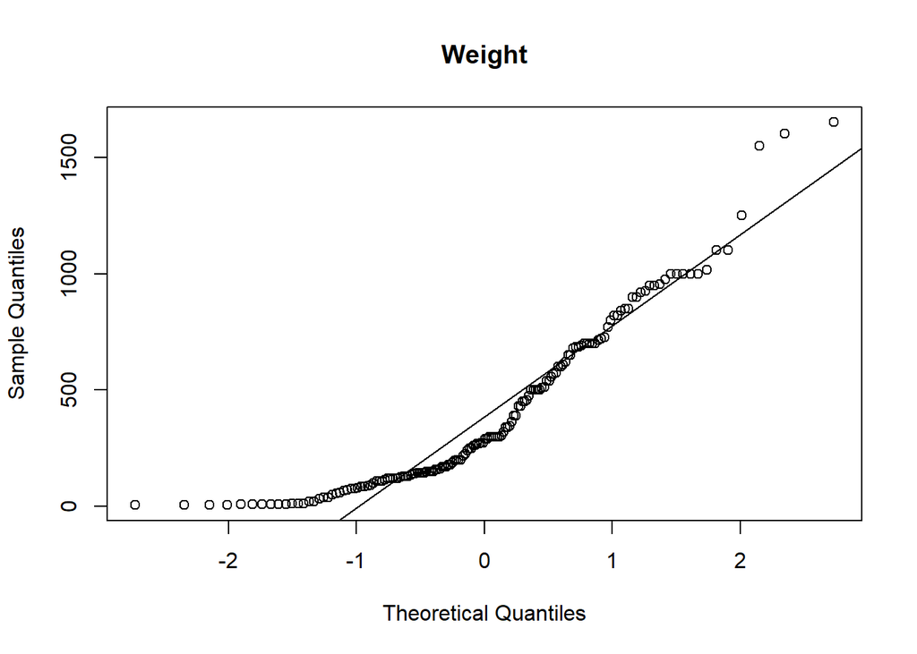

```r
qqnorm(fish[,"Weight"], main = "Weight")
qqline(fish[,"Weight"])
```

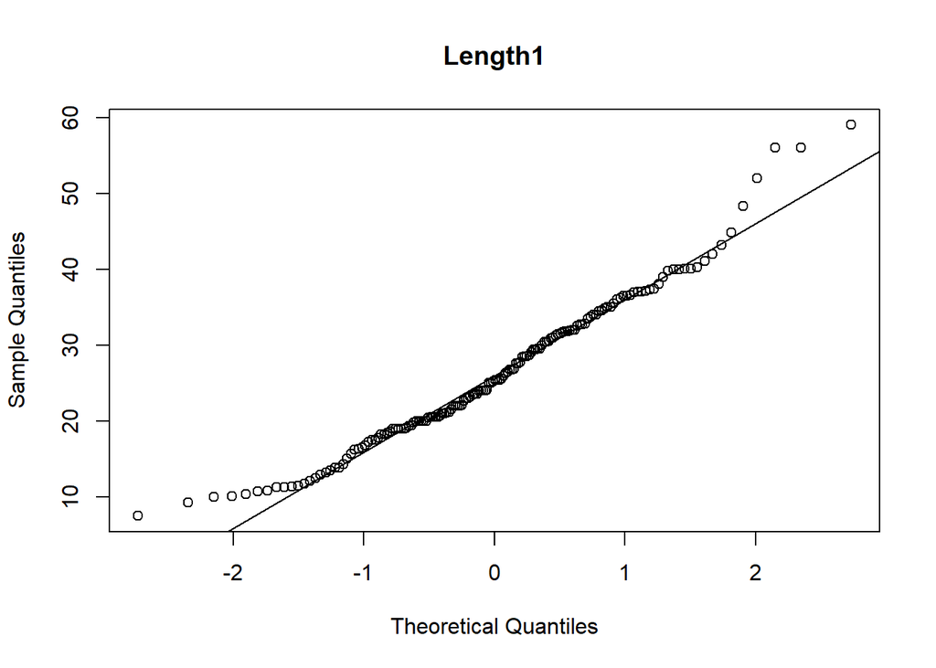

```r
qqnorm(fish[,"Length1"], main = "Length1")
qqline(fish[,"Length1"])
```

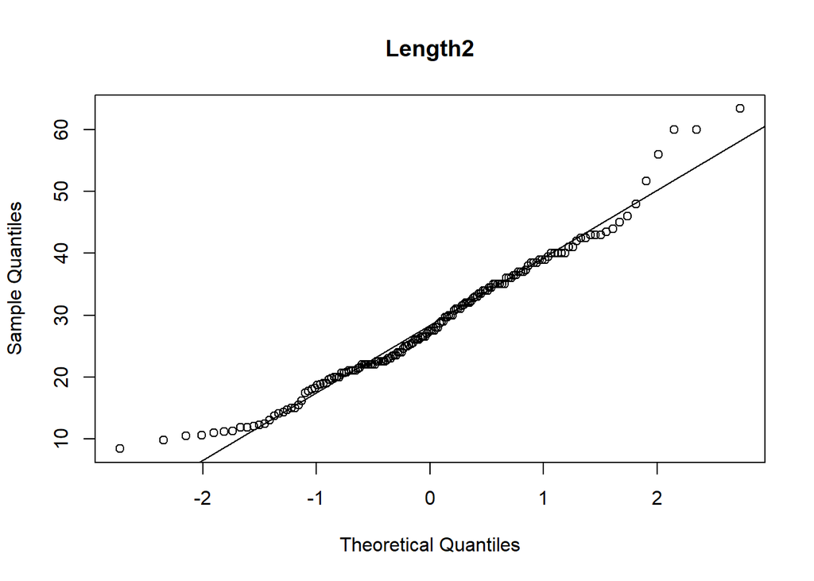

```r
qqnorm(fish[,"Length2"], main = "Length2")
qqline(fish[,"Length2"])
```

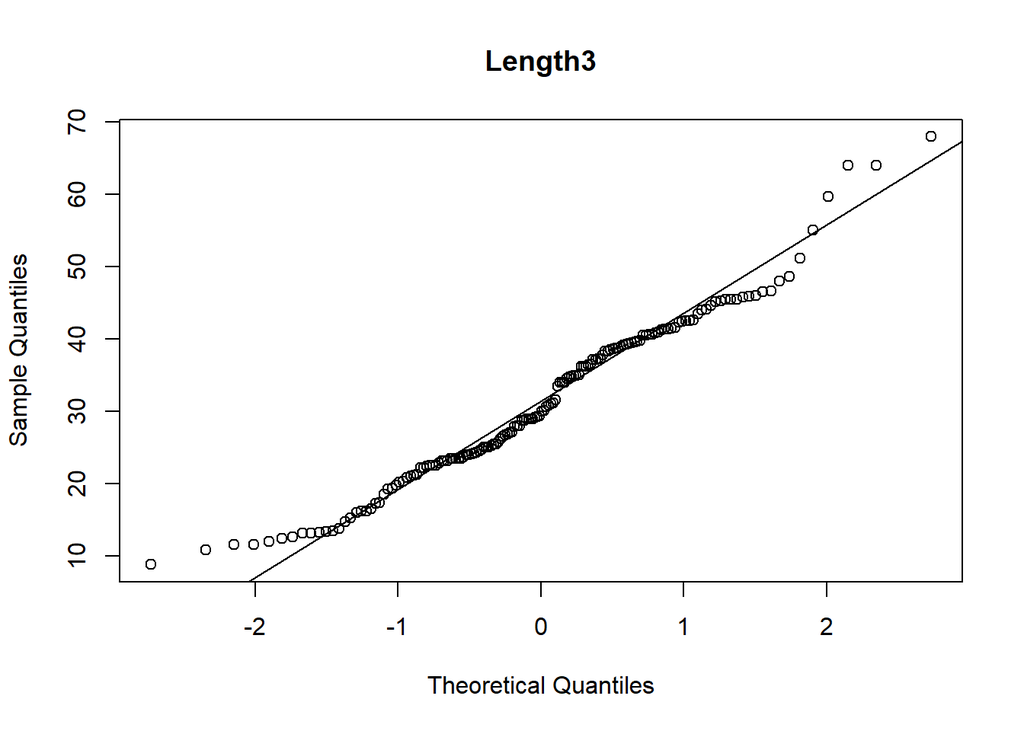

```r
qqnorm(fish[,"Length3"], main = "Length3")
qqline(fish[,"Length3"])
```

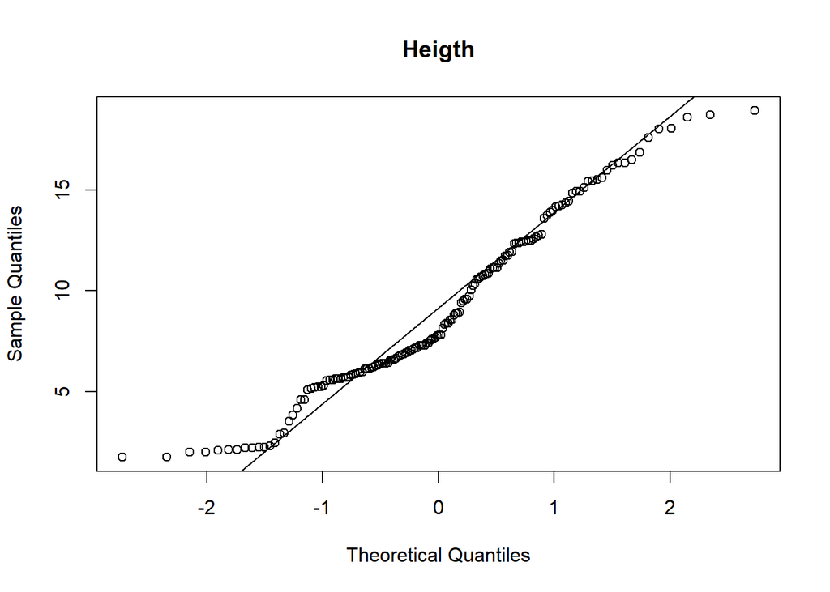

```r
qqnorm(fish[,"Height"], main = "Heigth")
qqline(fish[,"Height"])
```

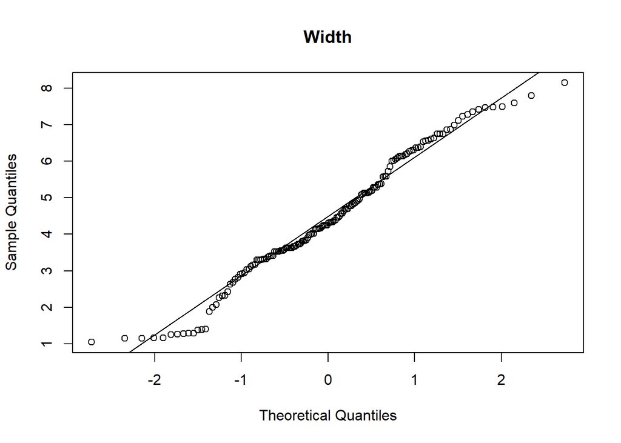

```r
qqnorm(fish[,"Width"], main = "Width")
qqline(fish[,"Width"])
```

This helps us compare the distribution for each independent column in our dataset. We can see that the Weight column is making an S shape so we can say that is it skewd which means points are not normally distributed. Similarly, for Height, it looks a little skewd. Length1, Length2, Length3 and Width seem to have most points closely follow the diagonal line which means they are normally distributed.

```r
#T-test
#with(data=fish,t.test(Weight,Height,var.equal=TRUE))
with(data=fish,t.test(Weight[Species=="Bream"],Weight[Species=="Roach"],var.equal=TRUE))
```

```
##
##  Two Sample t-test
##
## data:  Weight[Species == "Bream"] and Weight[Species == "Roach"]
## t = 9.1193, df = 52, p-value = 2.271e-12
## alternative hypothesis: true difference in means is not equal to 0
## 95 percent confidence interval:
##  357.0452 558.5066
## sample estimates:
## mean of x mean of y
##  617.8286  160.0526
```

```r
with(data=fish,t.test(Length1[Species=="Bream"],Length1[Species=="Roach"],var.equal=TRUE))
```

```
##
##  Two Sample t-test
##
## data:  Length1[Species == "Bream"] and Length1[Species == "Roach"]
## t = 9.4044, df = 52, p-value = 8.295e-13
## alternative hypothesis: true difference in means is not equal to 0
## 95 percent confidence interval:
##   7.531263 11.617008
## sample estimates:
## mean of x mean of y
##  30.30571  20.73158
```

```r
with(data=fish,t.test(Length2[Species=="Bream"],Length2[Species=="Roach"],var.equal=TRUE))
```

```
##
##  Two Sample t-test
##
## data:  Length2[Species == "Bream"] and Length2[Species == "Roach"]
## t = 9.792, df = 52, p-value = 2.137e-13
## alternative hypothesis: true difference in means is not equal to 0
## 95 percent confidence interval:
##   8.5392 12.9411
## sample estimates:
## mean of x mean of y
##  33.10857  22.36842
```

```r
with(data=fish,t.test(Length3[Species=="Bream"],Length3[Species=="Roach"],var.equal=TRUE))
```

```
##
##  Two Sample t-test
##
## data:  Length3[Species == "Bream"] and Length3[Species == "Roach"]
## t = 11.246, df = 52, p-value = 1.545e-15
## alternative hypothesis: true difference in means is not equal to 0
## 95 percent confidence interval:
##  10.90223 15.63792
## sample estimates:
## mean of x mean of y
##  38.35429  25.08421
```

```r
with(data=fish,t.test(Height[Species=="Bream"],Height[Species=="Roach"],var.equal=TRUE))
```

```
##
##  Two Sample t-test
##
## data:  Height[Species == "Bream"] and Height[Species == "Roach"]
## t = 16.884, df = 52, p-value < 2.2e-16
## alternative hypothesis: true difference in means is not equal to 0
## 95 percent confidence interval:
##  7.469406 9.484312
## sample estimates:
## mean of x mean of y
## 15.183211  6.706353
```

```r
with(data=fish,t.test(Width[Species=="Bream"],Width[Species=="Roach"],var.equal=TRUE))
```

```
##
##  Two Sample t-test
##
## data:  Width[Species == "Bream"] and Width[Species == "Roach"]
## t = 8.5952, df = 52, p-value = 1.477e-11
## alternative hypothesis: true difference in means is not equal to 0
## 95 percent confidence interval:
##  1.344238 2.163054
## sample estimates:
## mean of x mean of y
##  5.427614  3.673968
```

We are doing two sample t-test here to compare independent groups or populations. For eg, comparing means, hypothesis testing, EDA etc. Here we are comparing each column against the 2 unique values of Species column to see if they differ from each other in any way. We can perform this for all the species.

The p-value is extremely small, indicating strong evidence against the null hypothesis thus, we reject the null hypothesis and conclude that there is a significant difference in the mean weights of Bream and Roach fish.

```r
#hotelling
library(Hotelling)
t2testfish <- hotelling.test(Weight + Length1 + Length2 + Length3 + Height + Width ~ Species, data=fish)
cat("T2 statistic =",t2testfish$stat[[1]],"\n")
```

```
## T2 statistic = 819.7276
```

```r
print(t2testfish)
```

```
## Test stat:  819.73
## Numerator df:  6
## Denominator df:  39
## P-value:  0
```

Hotelling T2 test is a multivariate extension of two sample t-test. Here, we are comparing the multivariate means of the variables “Weight”, “Length1”, “Length2”, “Length3”, “Height”, and “Width” between different species of fish. The p-value is 0, which means it indicates strong evidence against the null hypothesis. The large test statistic indicates a substantial separation between the groups in the multivariate space.

```r
# F-test for Total length (not recommended)
attach(fish)
var.test(Width[Species=="Bream"],Width[Species=="Roach"])
```

```
##
##  F test to compare two variances
##
## data:  Width[Species == "Bream"] and Width[Species == "Roach"]
## F = 1.0462, num df = 34, denom df = 18, p-value = 0.9477
## alternative hypothesis: true ratio of variances is not equal to 1
## 95 percent confidence interval:
##  0.4329413 2.2735588
## sample estimates:
## ratio of variances
##           1.046159
```

We are perfroming F-test here. The p-value of 0.9477 is greater than the significance level, i.e 0.05 indicating weak evidence against the null hypothesis.Therefore, we fail to reject the null hypothesis. This suggests that there is no significant difference in the variances of the “Width” variable between the Bream and Roach species.

```r
print(unique(fish$Species))
```

```
## [1] "Bream"     "Roach"     "Whitefish" "Parkki"    "Perch"     "Pike"
## [7] "Smelt"
```

```r
matstand <- scale(fish[,2:7])
matstand
```

```
##             Weight       Length1     Length2      Length3      Height
##   [1,] -0.44408288 -0.3089507490 -0.28567896 -0.110115515  0.58977822
##   [2,] -0.30989139 -0.2290420634 -0.20181532 -0.006912838  0.81328400
##   [3,] -0.17010859 -0.2390306491 -0.18317895 -0.015513061  0.78948994
##   [4,] -0.10580850  0.0006954079  0.04977561  0.190892294  0.87148863
##   [5,]  0.08150045  0.0206725793  0.04977561  0.233893410  0.80490253
##   [6,]  0.13741357  0.0506383364  0.11500289  0.294094972  1.07459950
##   [7,]  0.27719637  0.0506383364  0.11500289  0.276894526  1.20895906
##   [8,] -0.03032579  0.1305470220  0.14295743  0.319895641  0.85751951
##   [9,]  0.13741357  0.1305470220  0.14295743  0.328495864  1.16830895
##  [10,]  0.27719637  0.2204442934  0.20818471  0.423098319  1.21992482
##  [11,]  0.20730497  0.2104557077  0.23613926  0.423098319  1.22835285
##  [12,]  0.27719637  0.2404214648  0.23613926  0.423098319  1.25363694
##  [13,]  0.27719637  0.2803758076  0.28273017  0.440298765  1.11110544
##  [14,] -0.17010859  0.3203301505  0.32932108  0.517700773  1.14688965
```

[output cut: 309 more lines]

```r
matbream <- matstand[Species == "Bream",]
matbream
```

```
##            Weight       Length1     Length2      Length3    Height       Width
##  [1,] -0.44408288 -0.3089507490 -0.28567896 -0.110115515 0.5897782 -0.23933056
##  [2,] -0.30989139 -0.2290420634 -0.20181532 -0.006912838 0.8132840 -0.07023739
##  [3,] -0.17010859 -0.2390306491 -0.18317895 -0.015513061 0.7894899  0.16096316
##  [4,] -0.10580850  0.0006954079  0.04977561  0.190892294 0.8714886  0.01851283
##  [5,]  0.08150045  0.0206725793  0.04977561  0.233893410 0.8049025  0.42022750
##  [6,]  0.13741357  0.0506383364  0.11500289  0.294094972 1.0745995  0.29790731
##  [7,]  0.27719637  0.0506383364  0.11500289  0.276894526 1.2089591  0.50578059
##  [8,] -0.03032579  0.1305470220  0.14295743  0.319895641 0.8575195  0.15735158
##  [9,]  0.13741357  0.1305470220  0.14295743  0.328495864 1.1683090  0.24841085
## [10,]  0.27719637  0.2204442934  0.20818471  0.423098319 1.2199248  0.31685332
## [11,]  0.20730497  0.2104557077  0.23613926  0.423098319 1.2283528  0.40258403
## [12,]  0.27719637  0.2404214648  0.23613926  0.423098319 1.2536369  0.23112261
## [13,]  0.27719637  0.2803758076  0.28273017  0.440298765 1.1111054 -0.03329267
## [14,] -0.17010859  0.3203301505  0.32932108  0.517700773 1.1468896  0.38399325
```

[output cut: 21 more lines]

```r
matroach <- matstand[Species == "Roach",]
matroach
```

```
##            Weight    Length1    Length2     Length3      Height       Width
##  [1,] -1.00880540 -1.3377751 -1.3386336 -1.29694631 -1.12674613 -1.27662473
##  [2,] -0.92773138 -0.9781860 -0.9565881 -0.94433716 -0.85874874 -0.94879951
##  [3,] -0.90257047 -0.8783001 -0.9006790 -0.86693515 -0.79418816 -0.89983591
##  [4,] -0.87740957 -0.8083800 -0.8074972 -0.78093292 -0.78464260 -0.73986052
##  [5,] -0.78515292 -0.7684257 -0.7888608 -0.78093292 -0.64509119 -0.50327219
##  [6,] -0.81310948 -0.7184828 -0.7143154 -0.70353091 -0.65633632 -0.60895542
##  [7,] -0.78515292 -0.6885170 -0.6956790 -0.65192957 -0.66869898 -0.66899059
##  [8,] -0.70128324 -0.5886311 -0.6024972 -0.56592734 -0.74089600 -0.39658246
##  [9,] -0.71526152 -0.5786426 -0.6024972 -0.60032823 -0.54779633 -0.51890265
## [10,] -0.67332668 -0.5786426 -0.5559063 -0.51432600 -0.45478533 -0.35756551
## [11,] -0.72923980 -0.5286996 -0.5559063 -0.54012667 -0.56732980 -0.65081426
## [12,] -0.67332668 -0.5187110 -0.5559063 -0.54012667 -0.60225258 -0.36958439
## [13,] -0.64816577 -0.4288138 -0.4161335 -0.35092176 -0.33814325 -0.34874378
## [14,] -0.67053102 -0.4288138 -0.4720426 -0.39392288 -0.48228120 -0.46952461
## [15,] -0.56150044 -0.4188252 -0.4627244 -0.38532266 -0.37017908 -0.17586141
## [16,] -0.61741356 -0.2689964 -0.3043153 -0.29072020 -0.44239939 -0.30682572
## [17,] -0.30989139 -0.2290421 -0.2297699 -0.17891730 -0.02560768  0.04296503
## [18,] -0.36021320 -0.1291562 -0.1365880 -0.05851418 -0.09750204  0.20684804
## [19,] -0.03032579  0.3203302  0.3013665  0.31989564  0.11599254  0.55107340
```

```r
matwhitefish <- matstand[Species == "Whitefish",]
matwhitefish
```

```
##          Weight     Length1     Length2     Length3      Height      Width
## [1,] -0.3658045 -0.26899641 -0.22976987 -0.22191842 -0.14117879 -0.1045770
## [2,] -0.3658045 -0.21905348 -0.18317895 -0.17031708 -0.19589114 -0.1040442
## [3,] -0.2651609 -0.06922469 -0.04340622 -0.04131373 -0.04861015  0.1523783
## [4,]  0.3890226  0.22044429  0.23613926  0.23389341  0.40911105  1.2656933
## [5,]  1.1158932  0.73985075  0.73932111  0.71550591  0.64593405  1.2725612
## [6,]  1.6750244  1.09943984  1.07477568  1.05091461  0.78394886  1.2437870
```

```r
matparkki <- matstand[Species == "Parkki",]
matparkki
```

```
##           Weight    Length1    Length2    Length3      Height      Width
##  [1,] -0.9668706 -1.2778436 -1.2827245 -1.2711456 -0.49806629 -1.2419891
##  [2,] -0.9528923 -1.1979349 -1.2081790 -1.1937436 -0.56099714 -1.2492714
##  [3,] -0.8690226 -0.9981632 -1.0031790 -0.9873383 -0.36822341 -1.0368393
##  [4,] -0.7851529 -0.8783001 -0.8820426 -0.8583349 -0.13843153 -0.8917247
##  [5,] -0.7012832 -0.7884029 -0.7888608 -0.7637325 -0.02188258 -0.6698787
##  [6,] -0.7292398 -0.7284713 -0.7236335 -0.6949307 -0.10457972 -0.6689314
##  [7,] -0.6453701 -0.7284713 -0.7236335 -0.6949307  0.09527169 -0.6002521
##  [8,] -0.7152615 -0.6485627 -0.6490881 -0.6175287  0.17452312 -0.7502216
##  [9,] -0.5615004 -0.5087225 -0.5093153 -0.4713249  0.31640272 -0.4503418
## [10,] -0.3574175 -0.3289279 -0.3229517 -0.2821200  0.48920062 -0.1659148
## [11,] -0.2819348 -0.2290421 -0.2297699 -0.1961177  0.55438981 -0.1126291
```

```r
matperch <- matstand[Species == "Perch",]
matperch
```

```
##           Weight     Length1     Length2     Length3     Height       Width
##  [1,] -1.1041373 -1.87715870 -1.86976999 -1.93336282 -1.6005784 -1.78579882
##  [2,] -1.0311706 -1.37772942 -1.37590631 -1.42594965 -1.2709074 -1.43577124
##  [3,] -1.0088054 -1.24787781 -1.25476994 -1.31414675 -1.2019931 -1.17952642
##  [4,] -0.9766554 -1.12801478 -1.14295175 -1.21094408 -1.0230953 -1.06135067
##  [5,] -0.9249357 -1.05809468 -1.03113356 -1.09914117 -1.0241197 -0.87787038
##  [6,] -0.8410660 -1.00815175 -0.97522447 -1.03893961 -0.8764197 -0.65282728
##  [7,] -0.9025705 -0.94822023 -0.90999719 -1.02173917 -0.8818211 -0.77017414
##  [8,] -0.8969792 -0.90826589 -0.88204264 -0.95293738 -0.7801725 -0.81351314
##  [9,] -0.8830009 -0.84833438 -0.82613355 -0.90133604 -0.8961627 -0.82144679
## [10,] -0.8830009 -0.80838003 -0.78886082 -0.88413560 -0.9091074 -0.97822504
## [11,] -0.8131095 -0.72847135 -0.69567899 -0.75513225 -0.7669717 -0.51463980
## [12,] -0.7991312 -0.72847135 -0.69567899 -0.75513225 -0.7145875 -0.66117536
## [13,] -0.7711746 -0.72847135 -0.69567899 -0.75513225 -0.7669717 -0.44803272
## [14,] -0.7571964 -0.69850559 -0.66772444 -0.72933158 -0.6059777 -0.52707312
```

[output cut: 42 more lines]

```r
matpike <- matstand[Species == "Pike",]
matpike
```

```
##            Weight   Length1   Length2   Length3      Height       Width
##  [1,] -0.56150044 0.3702731 0.3572756 0.3026952 -0.79595758 -0.62085588
##  [2,] -0.28193483 0.5400790 0.5156847 0.5607019 -0.76340956 -0.15762588
##  [3,] -0.28193483 0.6399649 0.6088666 0.6467041 -0.71018724 -0.02358284
##  [4,] -0.28193483 0.8497252 0.8231848 0.7327064 -0.62823512 -0.23944897
##  [5,]  0.08150045 0.9196453 0.8884120 0.7929079 -0.39504410  0.09015244
##  [6,] -0.15613031 0.9695882 0.9350029 0.8359090 -0.60318385 -0.26478926
##  [7,]  0.15418751 1.3691316 1.3077302 1.2229191 -0.39737228 -0.06023153
##  [8,]  0.30515293 1.3691316 1.3077302 1.2229191 -0.50330471  0.02058505
##  [9,]  0.38902261 1.3791202 1.3543212 1.2487197 -0.27956612  0.41762242
## [10,]  0.27719637 1.5689034 1.5406848 1.4379246 -0.47187421  0.27931653
## [11,]  0.46450533 1.6887664 1.6338666 1.4981262 -0.27816920  0.26392290
## [12,]  1.03202350 1.8485838 1.8202303 1.7131318 -0.30424488  0.56350672
## [13,]  1.53524159 2.1981843 2.1650030 2.0485405 -0.01410644  1.03431513
## [14,]  2.37393840 2.5677619 2.5656849 2.4441508  0.39567742  1.51607670
## [15,]  3.35241801 2.9673054 2.9384122 2.8139603  0.14276667  1.01821102
## [16,]  3.21263521 2.9673054 2.9384122 2.8139603  0.14276667  1.01821102
## [17,]  3.49220081 3.2669629 3.2552304 3.1579693  0.42494271  1.80920703
```

```r
matsmelt <- matstand[Species == "Smelt",]
matsmelt
```

```
##          Weight   Length1   Length2   Length3    Height     Width
##  [1,] -1.101901 -1.697364 -1.739315 -1.761358 -1.687466 -1.999178
##  [2,] -1.099664 -1.627444 -1.674088 -1.692557 -1.633173 -1.932630
##  [3,] -1.101062 -1.617455 -1.664770 -1.692557 -1.689888 -1.939498
##  [4,] -1.093514 -1.587490 -1.627497 -1.658156 -1.581022 -1.802377
##  [5,] -1.093234 -1.557524 -1.608861 -1.623755 -1.607284 -1.863241
##  [6,] -1.096309 -1.547535 -1.599543 -1.606554 -1.631729 -1.858504
##  [7,] -1.092675 -1.497592 -1.552952 -1.563553 -1.576854 -1.859333
##  [8,] -1.092955 -1.497592 -1.552952 -1.563553 -1.576854 -1.929137
##  [9,] -1.093234 -1.487604 -1.534315 -1.554953 -1.579066 -1.939498
## [10,] -1.086525 -1.477615 -1.515679 -1.537753 -1.605607 -1.794325
## [11,] -1.083170 -1.457638 -1.497043 -1.529152 -1.526542 -1.868096
## [12,] -1.086525 -1.417684 -1.441134 -1.503352 -1.562163 -1.875911
## [13,] -1.065557 -1.307809 -1.319997 -1.382949 -1.423450 -1.395511
## [14,] -1.064998 -1.247878 -1.254770 -1.296946 -1.409621 -1.506819
```

We are creating subsets of the standardized data (matstand) for each species of fish. Each subset contains only the rows corresponding to a specific species, obtained using conditional indexing based on the Species column.

```r
vecmedianbream <- apply(matbream, 2, median)
vecmedianbream
```

```
##    Weight   Length1   Length2   Length3    Height     Width
## 0.5847185 0.4102274 0.4225029 0.6209035 1.3893701 0.5067279
```

```r
vecmedianroach <- apply(matroach, 2, median)
vecmedianroach
```

```
##     Weight    Length1    Length2    Length3     Height      Width
## -0.7012832 -0.5786426 -0.5559063 -0.5401267 -0.5673298 -0.4695246
```

```r
vecmedianwhitefish <- apply(matwhitefish, 2, median)
vecmedianwhitefish
```

```
##     Weight    Length1    Length2    Length3     Height      Width
## 0.06193086 0.07560980 0.09636652 0.09628984 0.18025045 0.69808261
```

```r
vecmedianparkki <- apply(matparkki, 2, median)
vecmedianparkki
```

```
##      Weight     Length1     Length2     Length3      Height       Width
## -0.71526152 -0.72847135 -0.72363354 -0.69493069 -0.02188258 -0.66987869
```

```r
vecmedianperch <- apply(matperch, 2, median)
vecmedianperch
```

```
##     Weight    Length1    Length2    Length3     Height      Width
## -0.5405330 -0.3039565 -0.2949971 -0.3896228 -0.4807679 -0.1594613
```

```r
vecmedianpike <- apply(matpike, 2, median)
vecmedianpike
```

```
##     Weight    Length1    Length2    Length3     Height      Width
##  0.3051529  1.3791202  1.3543212  1.2487197 -0.3950441  0.2639229
```

```r
vecmediansmelt <- apply(matsmelt, 2, median)
vecmediansmelt
```

```
##    Weight   Length1   Length2   Length3    Height     Width
## -1.093094 -1.497592 -1.552952 -1.563553 -1.580044 -1.865668
```

Now we are calculating the median values for each variable (column) in the standardized data matrices for each species of fish.

```r
matabsdevbream <- abs(matbream - matrix(rep(vecmedianbream,nrow(matbream)),nrow=nrow(matbream), byrow=TRUE))
matabsdevroach <- abs(matroach - matrix(rep(vecmedianroach,nrow(matroach)),nrow=nrow(matroach), byrow=TRUE))
matabsdevwhitefish <- abs(matwhitefish - matrix(rep(vecmedianwhitefish,nrow(matwhitefish)),nrow=nrow(matwhitefish), byrow=TRUE))
matabsdevparkki <- abs(matparkki - matrix(rep(vecmedianparkki,nrow(matparkki)),nrow=nrow(matparkki), byrow=TRUE))
matabsdevperch <- abs(matperch - matrix(rep(vecmedianperch,nrow(matperch)),nrow=nrow(matperch), byrow=TRUE))
matabsdevpike <- abs(matpike - matrix(rep(vecmedianpike,nrow(matpike)),nrow=nrow(matpike), byrow=TRUE))
matabsdevsmelt <- abs(matsmelt - matrix(rep(vecmediansmelt,nrow(matsmelt)),nrow=nrow(matsmelt), byrow=TRUE))
```

Here we are calculating the absolute deviations of the standardized data matrices for each species of fish from their respective median vectors.

```r
matabsdev.all <- rbind(matabsdevbream, matabsdevroach, matabsdevwhitefish,matabsdevparkki,matabsdevperch, matabsdevpike,matabsdevsmelt)
matabsdev.all <- data.frame(Species, matabsdev.all)
```

Now we are combining the matrices of absolute deviations (matabsdevbream, matabsdevroach, etc.) for each species of fish into a single data frame and then adding a column for the species labels.

```r
unique_values <- unique(fish$Species)
results <- list()

for (col_name in names(matabsdev.all)) {
  if (col_name != "Species") {
    for (value in unique_values) {

      # Split the data into two groups based on the unique value
      group1 <- matabsdev.all[matabsdev.all$Species == value, col_name]
      group2 <- matabsdev.all[matabsdev.all$Species != value, col_name]

      # Perform the t-test
      t_result <- t.test(group1, group2)

      # Store the results
      result_entry <- list(
        Column = col_name,
        Group = value,
        TStatistic = t_result$statistic,
        PValue = t_result$p.value
      )
      results <- c(results, list(result_entry))
    }
  }
}

# Convert results to a data frame
results_df <- do.call(rbind, results)

# Print or further analyze the results
print(results_df)
```

```
##       Column    Group       TStatistic  PValue
##  [1,] "Weight"  "Bream"     -0.9004976  0.3695363
##  [2,] "Weight"  "Roach"     -5.956315   2.701918e-08
##  [3,] "Weight"  "Whitefish" 0.7526467   0.4815564
##  [4,] "Weight"  "Parkki"    -5.554682   6.22855e-07
##  [5,] "Weight"  "Perch"     2.785245    0.006510923
##  [6,] "Weight"  "Pike"      1.8868      0.07623152
##  [7,] "Weight"  "Smelt"     -9.956925   4.421025e-18
##  [8,] "Length1" "Bream"     -4.011311   0.0001015006
##  [9,] "Length1" "Roach"     -3.511177   0.00111853
## [10,] "Length1" "Whitefish" -0.1854207  0.8592677
## [11,] "Length1" "Parkki"    -3.183896   0.004833507
## [12,] "Length1" "Perch"     4.931996    4.094504e-06
## [13,] "Length1" "Pike"      1.889672    0.07479373
## [14,] "Length1" "Smelt"     -9.22808    1.059372e-15
```

[output cut: 28 more lines]

The output provides statistical evidence of differences in the measurements between different species of fish, helping to identify which measurements contribute significantly to distinguishing between species.

```r
matstand
```

```
##             Weight       Length1     Length2      Length3      Height
##   [1,] -0.44408288 -0.3089507490 -0.28567896 -0.110115515  0.58977822
##   [2,] -0.30989139 -0.2290420634 -0.20181532 -0.006912838  0.81328400
##   [3,] -0.17010859 -0.2390306491 -0.18317895 -0.015513061  0.78948994
##   [4,] -0.10580850  0.0006954079  0.04977561  0.190892294  0.87148863
##   [5,]  0.08150045  0.0206725793  0.04977561  0.233893410  0.80490253
##   [6,]  0.13741357  0.0506383364  0.11500289  0.294094972  1.07459950
##   [7,]  0.27719637  0.0506383364  0.11500289  0.276894526  1.20895906
##   [8,] -0.03032579  0.1305470220  0.14295743  0.319895641  0.85751951
##   [9,]  0.13741357  0.1305470220  0.14295743  0.328495864  1.16830895
##  [10,]  0.27719637  0.2204442934  0.20818471  0.423098319  1.21992482
##  [11,]  0.20730497  0.2104557077  0.23613926  0.423098319  1.22835285
##  [12,]  0.27719637  0.2404214648  0.23613926  0.423098319  1.25363694
##  [13,]  0.27719637  0.2803758076  0.28273017  0.440298765  1.11110544
##  [14,] -0.17010859  0.3203301505  0.32932108  0.517700773  1.14688965
```

[output cut: 309 more lines]

```r
matstand.all <- data.frame(Species, matstand)
colnames(matstand.all) <- colnames(fish[1:7])

t2testfish <- hotelling.test(Weight + Length1 + Length2 + Length3 + Height + Width ~ Species, data=matstand.all)
cat("T2 statistic =",t2testfish$stat[[1]],"\n")
```

```
## T2 statistic = 819.7276
```

```r
print(t2testfish)
```

```
## Test stat:  819.73
## Numerator df:  6
## Denominator df:  39
## P-value:  0
```

Here, the hotelling function is applied to the standardized data (matstand.all) with a formula specifying all the measurements. The high test statistic of 819.73 and a very low p-value 0 suggests that there are significant differences between the mean vectors of morphological measurements across different species of fish.

```r
matabsdev.all
```

```
##       Species       Weight     Length1    Length2     Length3       Height
## 1       Bream 1.0288014200 0.719178171 0.70818187 0.731018966 0.7995919100
## 2       Bream 0.8946099304 0.639269485 0.62431823 0.627816288 0.5760861350
## 3       Bream 0.7548271288 0.649258071 0.60568186 0.636416511 0.5998801873
## 4       Bream 0.6905270400 0.409532014 0.37272730 0.430011156 0.5178815061
## 5       Bream 0.5032180859 0.389554843 0.37272730 0.387010041 0.5844676016
## 6       Bream 0.4473049652 0.359589085 0.30750002 0.326808479 0.3147706331
## 7       Bream 0.3075221636 0.359589085 0.30750002 0.344008925 0.1804110678
## 8       Bream 0.6150443272 0.279680400 0.27954547 0.301007809 0.5318506171
## 9       Bream 0.4473049652 0.279680400 0.27954547 0.292407586 0.2210611806
## 10      Bream 0.3075221636 0.189783128 0.21431820 0.197805132 0.1694453157
## 11      Bream 0.3774135644 0.199771714 0.18636365 0.197805132 0.1610172854
## 12      Bream 0.3075221636 0.169805957 0.18636365 0.197805132 0.1357331946
## 13      Bream 0.3075221636 0.129851614 0.13977274 0.180604686 0.2782646899
## 14      Bream 0.7548271288 0.089897271 0.09318182 0.103202678 0.2424804840
```

[output cut: 303 more lines]

```r
d.all <- data.frame(Species,sqrt(rowSums(matabsdev.all[,-1]^2)))
d.all
```

```
##       Species sqrt.rowSums.matabsdev.all....1..2..
## 1       Bream                          1.951284274
## 2       Bream                          1.630240202
## 3       Bream                          1.497526633
## 4       Bream                          1.214468811
## 5       Bream                          1.021160381
## 6       Bream                          0.820629438
## 7       Bream                          0.685070541
## 8       Bream                          1.014978280
## 9       Bream                          0.746690340
## 10      Bream                          0.529538236
## 11      Bream                          0.541276756
## 12      Bream                          0.540040731
## 13      Bream                          0.729821372
## 14      Bream                          0.819170150
```

[output cut: 144 more lines]

```r
colnames(d.all)[2] <- "dij"
d.all
```

```
##       Species         dij
## 1       Bream 1.951284274
## 2       Bream 1.630240202
## 3       Bream 1.497526633
## 4       Bream 1.214468811
## 5       Bream 1.021160381
## 6       Bream 0.820629438
## 7       Bream 0.685070541
## 8       Bream 1.014978280
## 9       Bream 0.746690340
## 10      Bream 0.529538236
## 11      Bream 0.541276756
## 12      Bream 0.540040731
## 13      Bream 0.729821372
## 14      Bream 0.819170150
```

[output cut: 144 more lines]

```r
head(d.all)
```

```
##   Species       dij
## 1   Bream 1.9512843
## 2   Bream 1.6302402
## 3   Bream 1.4975266
## 4   Bream 1.2144688
## 5   Bream 1.0211604
## 6   Bream 0.8206294
```

```r
with(d.all, t.test(dij[Species=="Bream"], dij[Species=="Roach"],var.equal=TRUE, alternative="less"))
```

```
##
##  Two Sample t-test
##
## data:  dij[Species == "Bream"] and dij[Species == "Roach"]
## t = 1.6984, df = 52, p-value = 0.9523
## alternative hypothesis: true difference in means is less than 0
## 95 percent confidence interval:
##      -Inf 0.541588
## sample estimates:
## mean of x mean of y
## 0.8853294 0.6126315
```

```r
sprintf("d-values for Bream: Mean = %2.3f, Variance = %2.3f",mean(d.all$dij[Species=="Bream"]),var(d.all$dij[Species=="Bream"]))
```

```
## [1] "d-values for Bream: Mean = 0.885, Variance = 0.328"
```

```r
sprintf("d-values for Roach: Mean = %2.3f, Variance = %2.3f",mean(d.all$dij[Species=="Roach"]),var(d.all$dij[Species=="Roach"]))
```

```
## [1] "d-values for Roach: Mean = 0.613, Variance = 0.297"
```

Above code calculates Euclidean distances based on the absolute deviations (matabsdev.all) of standardized measurements. The p-value (0.9523) is greater than the significance level thus suggesting weak evidence against the null hypothesis. SImply, we don’t have enough evidence to conclude that there’s a significant difference in the average distance between these two species based on the given data.

```r
library(car)
#leveneTest() produces a two-sided test
leveneTest(Weight ~ Species, data=fish)
```

```
## Levene's Test for Homogeneity of Variance (center = median)
##        Df F value    Pr(>F)
## group   6   6.231 7.237e-06 ***
##       151
## ---
## Signif. codes:  0 '***' 0.001 '**' 0.01 '*' 0.05 '.' 0.1 ' ' 1
```

```r
leveneTest(Length1 ~ Species, data=fish)
```

```
## Levene's Test for Homogeneity of Variance (center = median)
##        Df F value    Pr(>F)
## group   6  9.3102 1.108e-08 ***
##       151
## ---
## Signif. codes:  0 '***' 0.001 '**' 0.01 '*' 0.05 '.' 0.1 ' ' 1
```

```r
leveneTest(Length2 ~ Species, data=fish)
```

```
## Levene's Test for Homogeneity of Variance (center = median)
##        Df F value    Pr(>F)
## group   6  8.8099 3.091e-08 ***
##       151
## ---
## Signif. codes:  0 '***' 0.001 '**' 0.01 '*' 0.05 '.' 0.1 ' ' 1
```

```r
leveneTest(Length3 ~ Species, data=fish)
```

```
## Levene's Test for Homogeneity of Variance (center = median)
##        Df F value    Pr(>F)
## group   6  8.0691 1.442e-07 ***
##       151
## ---
## Signif. codes:  0 '***' 0.001 '**' 0.01 '*' 0.05 '.' 0.1 ' ' 1
```

```r
leveneTest(Height ~ Species, data=fish)
```

```
## Levene's Test for Homogeneity of Variance (center = median)
##        Df F value    Pr(>F)
## group   6  6.1052 9.506e-06 ***
##       151
## ---
## Signif. codes:  0 '***' 0.001 '**' 0.01 '*' 0.05 '.' 0.1 ' ' 1
```

```r
leveneTest(Width ~ Species, data=fish)
```

```
## Levene's Test for Homogeneity of Variance (center = median)
##        Df F value    Pr(>F)
## group   6  8.5067 5.789e-08 ***
##       151
## ---
## Signif. codes:  0 '***' 0.001 '**' 0.01 '*' 0.05 '.' 0.1 ' ' 1
```

This code checks if the variability (spread) of measurements like weight, length, height, and width is similar or different across different types of fish species. Here, the test statistic is the F value, and a larger F value suggests larger differences in variances between groups.

The significance codes (**,** , ) show the level of significance at which we can reject the null hypothesis. In this case, *** indicates a very high level of significance.

In each test, the p-value is extremely small which indicates strong evidence against the null hypothesis.

Therefore, we reject the null hypothesis and conclude that there are significant differences in the variance of each measurement across the different types of species.